# Analyzing Co-Occurrences and Collocations in R

Martin Schweinberger

2020-12-13

# Introduction

This tutorial introduces collocation and co-occurrence analysis with *R* and shows how to extract and visualize semantic links between words. The entire R markdown document for the present tutorial can be downloaded [here](https://slcladal.github.io/collocations.Rmd). Parts of this tutorial build on and use materials from [this tutorial](https://tm4ss.github.io/docs/Tutorial_5_Co-occurrence.html) on co-occurrence analysis with R by Andreas Niekler and Gregor Wiedemann (see Wiedemann and Niekler 2017).

How would you find words that are associated with a specific term and how can you visualize such word nets? This tutorial addresses this issue by focusing on co-occurrence and collocations of words. Collocations are words that occur very frequently together. For example, *Merry Christmas* is a collocation because *merry* and *Christmas* occur more frequently together than would be expected by chance. This means that if you were to shuffle all words in a corpus and would then test the frequency of how often *merry* and *Christmas* co-occurred, they would occur significantly less often in the shuffled or randomized corpus than in a corpus that contain non-shuffled natural speech.

But how can you determine if words occur more frequently together than would be expected by chance? This tutorial will answer this question.

## Preparation and session set up

This tutorial is based on R. If you have not installed R or are new to it, you will find an introduction to and more information how to use R [here](https://slcladal.github.io/IntroR_workshop.html). For this tutorials, we need to install certain *packages* from an R *library* so that the scripts shown below are executed without errors. Before turning to the code below, please install the packages by running the code below this paragraph. If you have already installed the packages mentioned below, then you can skip ahead ignore this section. To install the necessary packages, simply run the following code - it may take some time (between 1 and 5 minutes to install all of the libraries so you do not need to worry if it takes some time).

```r
# clean current workspace
rm(list=ls(all=T))
# set options
options(stringsAsFactors = F)
options(scipen = 999)
options(max.print=10000)
# install packages
install.packages("corpus", "tidyverse", "quanteda", "tm",
                 "GGally", "network", "sna", "collostructions")
```

Once you have installed R-Studio and initiated the session by executing the code shown above, you are good to go.

# 1 Extracting N-Grams and Collocations

Collocations are terms that co-occur (significantly) more often together than would be expected by chance. A typical example of a collocation is *Merry Christmas* because the words *merry* and *Christmas* occur together more frequently together than would be expected, if words were just randomly stringed together.

N-grams are related to collocates in that they represent words that occur together (bi-grams are two words that occur together, tri-grams three words and so on). Fortunately, creating N-gram lists is very easy. We will use the Charles Darwin’s *On the Origin of Species by Means of Natural Selection* as a data source and begin by generating a bi-gram list. As a first step, we load the data and split it into individual words.

```r
# load libraries
library(tidyverse)
library(quanteda)
library(tidytext)
library(tm)
library(DT)
# read in text
darwin <- readLines("https://slcladal.github.io/data/origindarwin.txt") %>%
  paste(sep = " ", collapse = " ") %>%
  stringr::str_squish() %>%
  stringr::str_remove_all("- ")
# further processing
darwin_split <- darwin %>%
  as_tibble() %>%
  tidytext::unnest_tokens(words, value)
# inspect data
head(darwin_split, 15)
```

```
## # A tibble: 15 x 1
##    words
##    <chr>
##  1 the
##  2 origin
##  3 of
##  4 species
##  5 by
##  6 charles
##  7 darwin
##  8 an
##  9 historical
## 10 sketch
## 11 of
## 12 the
## 13 progress
## 14 of
## 15 opinion
```

We can create bi-grams (N-grams consisting of two elements) by pasting every word together with the ford that immediately follows it. To do this, we could use a function that is already available but we can also very simply to this manually. The first step in creating bigrams manually consists in creating a table which holds every word in a corpus and the word that immediately precedes it.

```r
# create data frame
darwin_words <- darwin_split %>%
  dplyr::rename(word1 = words) %>%
  dplyr::mutate(word2 = c(word1[2:length(word1)], NA)) %>%
  na.omit()
# inspect results
head(darwin_words, 15)
```

```
## # A tibble: 15 x 2
##    word1      word2
##    <chr>      <chr>
##  1 the        origin
##  2 origin     of
##  3 of         species
##  4 species    by
##  5 by         charles
##  6 charles    darwin
##  7 darwin     an
##  8 an         historical
##  9 historical sketch
## 10 sketch     of
## 11 of         the
## 12 the        progress
## 13 progress   of
## 14 of         opinion
## 15 opinion    on
```

We can the paste the elements in these two column together and also inspect the frequency of each bigram.

```r
darwin2grams <- darwin_words %>%
  dplyr::mutate(bigram = paste(word1, word2, sep = " ")) %>%
  dplyr::group_by(bigram) %>%
  dplyr::summarise(frequency = n()) %>%
  dplyr::arrange(-frequency)
# inspect results
head(darwin2grams, 15)
```

```
## # A tibble: 15 x 2
##    bigram            frequency
##    <chr>                 <int>
##  1 of the                 2673
##  2 in the                 1440
##  3 the same                959
##  4 to the                  790
##  5 on the                  743
##  6 have been               624
##  7 that the                574
##  8 it is                   500
##  9 natural selection       405
## 10 and the                 350
## 11 from the                346
## 12 in a                    339
## 13 of a                    337
## 14 with the                336
## 15 to be                   324
```

The table show that among the 15 most frequent bigrams, there is only a single bigram (*natural selection*) which does not involve stop words (words that do not have referential but only relational meaning).

We can remove bigrams that include stops words rather easily as shown below.

```r
# define stopwords
stps <- paste0(tm::stopwords(kind = "en"), collapse = "\\b|\\b")
# clean bigram table
darwin2grams_clean <- darwin2grams %>%
  dplyr::filter(!str_detect(bigram, stps))
# inspect results
head(darwin2grams_clean, 15)
```

```
## # A tibble: 15 x 2
##    bigram               frequency
##    <chr>                    <int>
##  1 natural selection          405
##  2 organic beings             107
##  3 distinct species           106
##  4 one species                 74
##  5 closely allied              73
##  6 widely different            52
##  7 allied species              48
##  8 can understand              47
##  9 can see                     44
## 10 new species                 44
## 11 south america               44
## 12 modified descendants        43
## 13 physical conditions         42
## 14 fresh water                 40
## 15 will generally              38
```

## Extracting N-Grams with quanteda

The `quanteda` package (see Benoit et al. 2018) offers excellent and very fast functions for extracting bigrams.

```r
#clean corpus
darwin_clean <- darwin %>%
  stringr::str_to_title()
# tokenize corpus
darwin_tokzd <- quanteda::tokens(darwin_clean)
# extract bigrams
BiGrams <- darwin_tokzd %>%
       quanteda::tokens_remove(stopwords("en")) %>%
       quanteda::tokens_select(pattern = "^[A-Z]",
                               valuetype = "regex",
                               case_insensitive = FALSE,
                               padding = TRUE) %>%
       quanteda::textstat_collocations(min_count = 5, tolower = FALSE)
# inspect results
head(BiGrams)
```

```
##         collocation count count_nested length   lambda        z
## 1 Natural Selection   405            0      2 8.036631 59.06645
## 2   Conditions Life   119            0      2 5.935487 43.39652
## 3    Organic Beings   107            0      2 8.489500 38.51339
## 4    Closely Allied    64            0      2 6.790687 35.11630
## 5     South America    44            0      2 7.626687 30.32076
## 6  Widely Different    51            0      2 5.466179 29.70147
```

We can also extract bigrams very easily using the `tokens_compound` function which understands that we are looking for two-word expressions.

```r
ngram_extract <- quanteda::tokens_compound(darwin_tokzd, pattern = BiGrams)
# inspect kwic of two bigrams
head(kwic(ngram_extract, pattern = c("Natural_Selection", "South_America")), 15)
```

```
##
##     [text1, 47] Distribution Of The Organic_Beings Inhabiting |   South_America   | , And In The Geological
##   [text1, 1330]                 . This Fundamental Subject Of | Natural_Selection | Will Be Treated At Some
##   [text1, 1347]                         We Shall Then See How | Natural_Selection | Almost_Inevitably Causes Much_Extinction Of The
##   [text1, 1773]                         , I Am Convinced That | Natural_Selection | Has Been The Most Important
##  [text1, 13185]                              By A Process Of" | Natural_Selection | ," As Will Hereafter
##  [text1, 16129]               They Thus Aft'ord Materials For | Natural_Selection | To Act On And Accumulate
##  [text1, 16662]                   On And Rendered Definite By | Natural_Selection | , As Hereafter To Be
##  [text1, 19792]                   To The Cumulative Action Of | Natural_Selection | , Hereafter To Be Explained
##  [text1, 22519]                  For Existence Its Bearing On | Natural_Selection | - The Term Used In
##  [text1, 22633]               Struggle For Existence Bears On | Natural_Selection | . It Has Been Seen
##  [text1, 23075]                        Preserved, By The Term | Natural_Selection | , In Order To Mark
##  [text1, 23154]                           Hand Of Nature. But | Natural_Selection | , As We Shall_Hereafter_See,
##  [text1, 24227]            Slow-Breeding Cattle And Horses In |   South_America   | , And Latterly In Australia
##  [text1, 25171]                       To The Feral Animals Of |   South_America   | . Here I Will Make
##  [text1, 27176]                     Have Observeu In Parts Of |   South_America   | ) The Vegetation: This
```

The disadvantage here is that we are strictly speaking only extracting N-Grams but not collocates as collocates do not necessarily have to occur in direct adjacency. The following section shoes how to expand the extraction of n-grams to the extraction of collocates.

# 2 Finding Collocations

Both N-grams and collocations are not only an important concept in language teaching but they are also fundamental in Text Analysis and many other research areas working with language data. Unfortunately, words that collocate do not have to be immediately adjacent but can also encompass several slots. This is unfortunate because it makes retrieval of collocates substantially more difficult compared with a situation in which we only need to extract words that occur right next to each other.

In the following, we will extract collocations from Charles Darwin’s *On the Origin of Species by Means of Natural Selection*. In a first step, we will split the Origin into individual sentences.

```r
# read in text
darwinsentences <- darwin %>%
  stringr::str_squish() %>%
  stringr::str_replace_all("([A-Z]{2,} [A-Z]{2,}) ([A-Z][a-z]{1,} )", "\\1 qwertz\\2") %>%
  stringr::str_replace_all("([a-z]{2,}\\.) ([A-Z] {0,1}[a-z]{0,30})", "\\1qwertz\\2") %>%
  stringr::str_replace_all("([a-z]{2,}\\?) ([A-Z] {0,1}[a-z]{0,30})", "\\1qwertz\\2") %>%
  strsplit("qwertz")%>%
  unlist() %>%
  stringr::str_remove_all("- ") %>%
  stringr::str_replace_all("\\W", " ") %>%
  stringr::str_squish()
# inspect data
head(darwinsentences)
```

```
## [1] "THE ORIGIN OF SPECIES BY CHARLES DARWIN AN HISTORICAL SKETCH OF THE PROGRESS OF OPINION ON THE ORIGIN OF SPECIES INTRODUCTION"
## [2] "When on board H M S Beagle as naturalist I was much struck with certain facts in the distribution of the organic beings inhabiting South America and in the geological relations of the present to the past inhabitants of that continent"
## [3] "These facts as will be seen in the latter chapters of this volume seemed to throw some light on the origin of species that mystery of mysteries as it has been called by one of our greatest philosophers"
## [4] "On my return home it occurred to me in 1837 that something might perhaps be made out on this question by patiently accumulating and reflecting on all sorts of facts which could possibly have any bearing on it"
## [5] "After five years work I allowed myself to speculate on the subject and drew up some short notes these I enlarged in 1844 into a sketch of the conclusions which then seemed to me probable from that period to the present day I have steadily pursued the same object"
## [6] "I hope that I may be excused for entering on these personal details as I give them to show that I have not been hasty in coming to a decision"
```

```r
# convert into corpus
darwincorpus <- Corpus(VectorSource(darwinsentences))
# create vector with words to remove
extrawords <- c("the", "can", "get", "got", "can", "one",
                "dont", "even", "may", "but", "will",
                "much", "first", "but", "see", "new",
                "many", "less", "now", "well", "like",
                "often", "every", "said", "two")
# clean corpus
darwincorpusclean <- darwincorpus %>%
  tm::tm_map(removePunctuation) %>%
  tm::tm_map(removeNumbers) %>%
  tm::tm_map(tolower) %>%
  tm::tm_map(removeWords, stopwords()) %>%
  tm::tm_map(removeWords, extrawords)
# create document term matrix
darwindtm <- DocumentTermMatrix(darwincorpusclean, control=list(bounds = list(global=c(1, Inf)), weighting = weightBin))
# load library
library(Matrix)
# convert dtm into sparse matrix
darwinsdtm <- sparseMatrix(i = darwindtm$i, j = darwindtm$j,
                           x = darwindtm$v,
                           dims = c(darwindtm$nrow, darwindtm$ncol),
                           dimnames = dimnames(darwindtm))
# calculate co-occurrence counts
coocurrences <- t(darwinsdtm) %*% darwinsdtm
# convert into matrix
collocates <- as.matrix(coocurrences)
# inspect results
datatable(collocates[1:10, 1:10], rownames = T, options = list(pageLength = 10, scrollX=T), filter = "none")
```

|  | charles | darwin | historical | introduction | opinion | origin | progress | sketch | species | america |
| --- | --- | --- | --- | --- | --- | --- | --- | --- | --- | --- |
| charles | 9 | 1 | 1 | 1 | 1 | 1 | 1 | 1 | 2 | 0 |
| darwin | 1 | 3 | 1 | 1 | 1 | 1 | 1 | 1 | 1 | 0 |
| historical | 1 | 1 | 4 | 1 | 1 | 2 | 1 | 1 | 3 | 0 |
| introduction | 1 | 1 | 1 | 7 | 1 | 2 | 1 | 1 | 4 | 2 |
| opinion | 1 | 1 | 1 | 1 | 10 | 1 | 1 | 1 | 6 | 0 |
| origin | 1 | 1 | 2 | 2 | 1 | 55 | 1 | 1 | 24 | 1 |
| progress | 1 | 1 | 1 | 1 | 1 | 1 | 19 | 1 | 6 | 2 |
| sketch | 1 | 1 | 1 | 1 | 1 | 1 | 1 | 4 | 1 | 0 |
| species | 2 | 1 | 3 | 4 | 6 | 24 | 6 | 1 | 1286 | 32 |
| america | 0 | 0 | 0 | 2 | 0 | 1 | 2 | 0 | 32 | 105 |

```r
# inspect size of matrix
ncol(collocates)
```

```
## [1] 8638
```

```r
summary(rowSums(collocates))
```

```
##    Min. 1st Qu.  Median    Mean 3rd Qu.    Max.
##     1.0    24.0    50.0   218.2   150.0 25435.0
```

We will now use an example of one individual word (*selection*) to show, how collocation strength for individual terms is calculated and how it can be visualized or displayed. The function `calculateCoocStatistics` is taken from [this tutorial](https://tm4ss.github.io/docs/Tutorial_5_Co-occurrence.html) (see also Wiedemann and Niekler 2017).

```r
# load function for co-occurrence calculation
source("https://slcladal.github.io/rscripts/calculateCoocStatistics.R")
# define term
coocTerm <- "selection"
# calculate cooccurence statistics
coocs <- calculateCoocStatistics(coocTerm, darwinsdtm, measure="LOGLIK")
# inspect results
coocs[1:20]
```

```
##       natural        theory    variations       effects modifications          acts         power        disuse   accumulated     advantage
##    1676.86794     116.78319     109.25728      68.08654      53.66782      49.41167      47.51319      44.62212      43.33924      43.24189
##        slight        sexual     variation     principle        useful        action  preservation      survival    favourable      rendered
##      42.23520      40.40298      38.06813      37.00670      35.56756      34.22504      34.16343      34.03879      31.11955      30.53940
```

# 3 Visualizing Collocations

There are various visualizations options for collocations. Which visualization method is appropriate depends on what the visualizations should display.

## Association Strength

We start with the most basic and visualize the collocation strength using a simple dot chart.

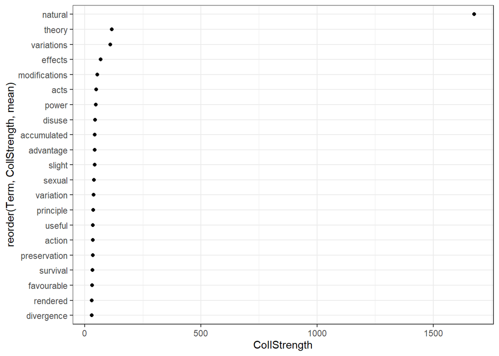

```r
coocdf <- coocs %>%
  as.data.frame() %>%
  dplyr::mutate(CollStrength = coocs,
                Term = names(coocs)) %>%
  dplyr::filter(CollStrength > 30)
# plot
ggplot(coocdf, aes(x = reorder(Term, CollStrength, mean), y = CollStrength)) +
  geom_point() +
  coord_flip() +
  theme_bw()
```

The dot chart shows that *natural* is collocating more strongly with *selection* compared to any other term. This substantiates that *natural* and *selection* are a collocation in Darwin’s *On the Origin of Species by Means of Natural Selection* (which is unsurprising, of course).

## Dendrograms

Another method for visualizing collocations are dendrograms. Dendrograms (also called tree-diagrams) show how similar elements are based on one or many features. As such, dendrograms are sued to indicate groupings as they show elements (words) that are notably similar or different with respect to their association strength. To use this method, we first need to generate a distance matrix from our co-occurrence matrix.

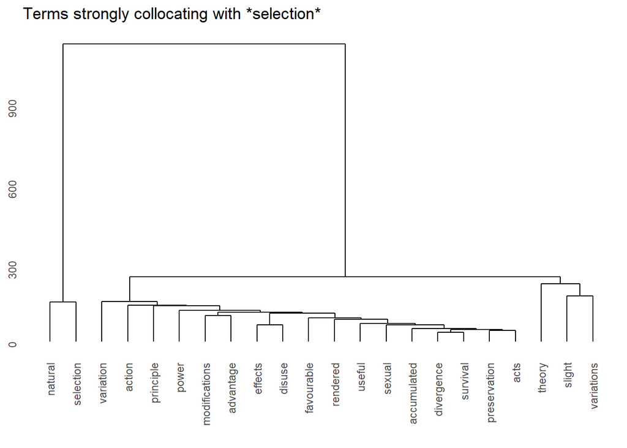

```r
coolocs <- c(coocdf$Term, "selection")
# remove non-collocating terms
collocates_redux <- collocates[rownames(collocates) %in% coolocs, ]
collocates_redux <- collocates_redux[, colnames(collocates_redux) %in% coolocs]
# create distance matrix
distmtx <- dist(collocates_redux)
# activate library
library("cluster")         # activate library
clustertexts <- hclust(    # hierarchical cluster object
  distmtx,                 # use distance matrix as data
  method="ward.D2")        # ward.D as linkage method
library(ggdendro)
ggdendrogram(clustertexts) +
  ggtitle("Terms strongly collocating with *selection*")
```

## Network Graphs

Network graphs are a very useful tool to show relationships (or the absence of relationships) between elements. Network graphs are highly useful when it comes to displaying the relationships that words have among each other and which properties these networks of words have.

### Basic Network Graphs

In order to display a network, we need to create a network graph by using the `network` function from the `network` package.

```r
library(network)
net = network::network(collocates_redux,
                       directed = FALSE,
                       ignore.eval = FALSE,
                       names.eval = "weights")
# vertex names
network.vertex.names(net) = rownames(collocates_redux)
# inspect object
net
```

```
##  Network attributes:
##   vertices = 22
##   directed = FALSE
##   hyper = FALSE
##   loops = FALSE
##   multiple = FALSE
##   bipartite = FALSE
##   total edges= 201
##     missing edges= 0
##     non-missing edges= 201
##
##  Vertex attribute names:
##     vertex.names
##
##  Edge attribute names:
##     weights
```

Now that we have generated a network object, we visualize the network.

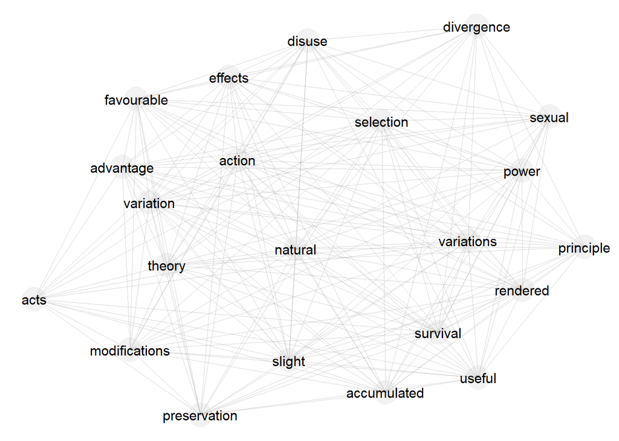

```r
library(GGally)
ggnet2(net,
       label = TRUE,
       label.size = 4,
       alpha = 0.2,
       size.cut = 3,
       edge.alpha = 0.3) +
  guides(color = FALSE, size = FALSE)
```

The network is already informative but we will customize the network object so that the visualization becomes more appealing and informative. To add information, we create vector of words that contain different groups, e.g. terms that rarely, sometimes, and frequently collocate with *selection* (I used the dendrogram which displayed the cluster analysis as the basis for the categorization).

Based on these vectors, we can then change or adapt the default values of certain attributes or parameters of the network object (e.g. weights. linetypes, and colors).

```r
# create vectors with collocation occurrences as categories
mid <- c("theory", "variations", "slight", "variation")
high <- c("natural", "selection")
infreq <- colnames(collocates_redux)[!colnames(collocates_redux) %in% mid & !colnames(collocates_redux) %in% high]
# add color by group
net %v% "Collocation" = ifelse(network.vertex.names(net) %in% infreq, "weak",
                   ifelse(network.vertex.names(net) %in% mid, "medium",
                   ifelse(network.vertex.names(net) %in% high, "strong", "other")))
# modify color
net %v% "color" = ifelse(net %v% "Collocation" == "weak", "gray60",
                  ifelse(net %v% "Collocation" == "medium", "orange",
                  ifelse(net %v% "Collocation" == "strong", "indianred4", "gray60")))
# rescale edge size
network::set.edge.attribute(net, "weights", ifelse(net %e% "weights" < 1, 0.1,
                                   ifelse(net %e% "weights" <= 2, .5, 1)))
# define line type
network::set.edge.attribute(net, "lty", ifelse(net %e% "weights" <=.1, 3,
                               ifelse(net %e% "weights" <= .5, 2, 1)))
```

We can now display the network object and make use of the added information.

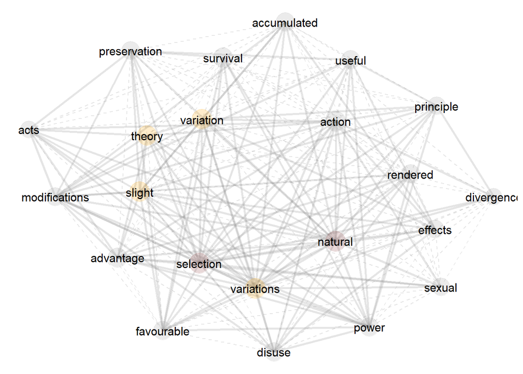

```r
ggnet2(net,
       color = "color",
       label = TRUE,
       label.size = 4,
       alpha = 0.2,
       size = "degree",
       edge.size = "weights",
       edge.lty = "lty",
       edge.alpha = 0.2) +
  guides(color = FALSE, size = FALSE)
```

### Advanced Network Graphs

Wiedemann and Niekler (2017) have written a very recommendable tutorial on co-occurrence analysis and they propose an alternative, yet more complex network visualization for co-occurrences. Their approach is to create and customize a graph object based on the `iGraph` package.

The code below is based on [this tutorial](https://tm4ss.github.io/docs/Tutorial_5_Co-occurrence.html) and is included to show the flexibility of the approach used by Wiedemann and Niekler (2017).

```r
numberOfCoocs <- 12
# create graph object
resultGraph <- data.frame(from = character(), to = character(), sig = numeric(0))
# create data frame
tmpGraph <- data.frame(from = character(), to = character(), sig = numeric(0))
# fill data frame to produce the correct number of lines
tmpGraph[1:numberOfCoocs, 3] <- coocs[1:numberOfCoocs]
# enter search word into the first column in all lines
tmpGraph[, 1] <- coocTerm
# enter co-occurrences into second column
tmpGraph[, 2] <- names(coocs)[1:numberOfCoocs]
# enter collocation strength
tmpGraph[, 3] <- coocs[1:numberOfCoocs]
# attach data frame to resultGraph
resultGraph <- rbind(resultGraph, tmpGraph)
```

Calculate cooccurence statistics and add them to the graph object.

```r
# iterate over most significant numberOfCoocs co-occurrences
for (i in 1:numberOfCoocs){
  # calculate co-occurrence strength for term i
  newCoocTerm <- names(coocs)[i]
  coocs2 <- calculateCoocStatistics(newCoocTerm, darwinsdtm, measure="LOGLIK")
  # fill temporary graph object
  tmpGraph <- data.frame(from = character(), to = character(), sig = numeric(0))
  tmpGraph[1:numberOfCoocs, 3] <- coocs2[1:numberOfCoocs]
  tmpGraph[, 1] <- newCoocTerm
  tmpGraph[, 2] <- names(coocs2)[1:numberOfCoocs]
  tmpGraph[, 3] <- coocs2[1:numberOfCoocs]
  # append results to the result graph data frame
  resultGraph <- rbind(resultGraph, tmpGraph[2:length(tmpGraph[, 1]), ])
}
```

Now, we can create a network graph object.

```r
# load packages
library(igraph)
# define graph and type ("F" means "Force Directed")
graphNetwork <- graph.data.frame(resultGraph, directed = F)
# identify nodes with fewer than 2 edges
graphVs <- V(graphNetwork)[degree(graphNetwork) < 2]
# removed these edges from graph
graphNetwork <- delete.vertices(graphNetwork, graphVs)
# assign colors to edges and nodes (search term blue, rest orange)
V(graphNetwork)$color <- ifelse(V(graphNetwork)$name == coocTerm, 'cornflowerblue', 'orange')
# Edges with a significance of at least 50% of the maximum significance in the graph are drawn in orange
halfMaxSig <- max(E(graphNetwork)$sig) * 0.5
E(graphNetwork)$color <- ifelse(E(graphNetwork)$sig > halfMaxSig, "coral", "azure3")
# disable edges with radius
E(graphNetwork)$curved <- 0
# size the nodes by their degree of networking
V(graphNetwork)$size <- log(degree(graphNetwork)) * 5
# all nodes must be assigned a standard minimum-size
V(graphNetwork)$size[V(graphNetwork)$size < 5] <- 3
# edge thickness
E(graphNetwork)$width <- 1.5
```

And finally, we can visualize the network.

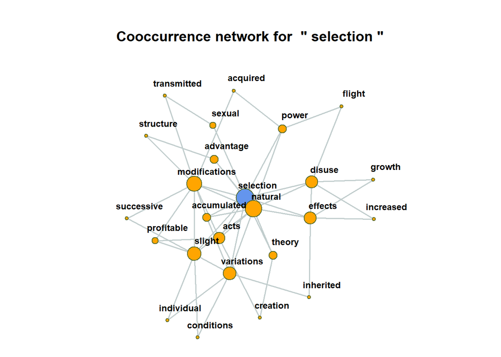

```r
# Define the frame and spacing for the plot
par(mai=c(0,0,1,0))
# Finaler Plot
plot(graphNetwork,
     layout = layout.fruchterman.reingold,  # Force Directed Layout
     main = paste("Cooccurrence network for", " \"", coocTerm, "\""),
     vertex.label.family = "sans",
     vertex.label.cex = .75,
     vertex.shape = "circle",
     vertex.label.dist = 2,           # Labels of the nodes moved slightly
     vertex.frame.color = 'darkolivegreen',
     vertex.label.color = 'black',      # Color of node names
     vertex.label.font = 2,         # Font of node names
     vertex.label = V(graphNetwork)$name,       # node names
     vertex.label.cex = .75 # font size of node names
)
```

The advantage of this more elaborate technique to visualize network lies in its flexibility. In contrast to the basic network visualization shown above, this network object can be customized to show very specific aspects of the data.

## Biplots

An alternative way to display co-occurrence patterns are bi-plots which are used to display the results of Correspondence Analyses. They are useful, in particular, when one is not interested in one particular key term and its collocations but in the overall similarity of many terms. Semantic similarity in this case refers to a shared semantic and this distributional profile. As such, words can be deemed semantically similar if they have a similar co-occurrence profile - i.e. they co-occur with the same elements. Biplots can be sued to visualize collocations because collocates co-occur and thus share semantic properties which renders then more similar to each other compared with other terms.

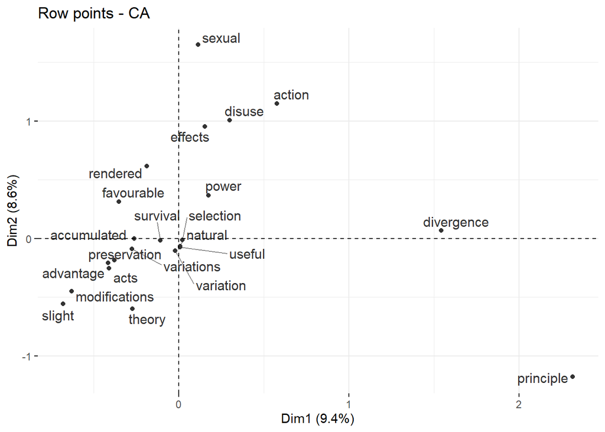

```r
# load packages
library(FactoMineR)
library(factoextra)
# perform correspondence analysis
res.ca <- CA(collocates_redux, graph = FALSE)
# plot results
fviz_ca_row(res.ca, repel = TRUE, col.row = "gray20")
```

# 4 Determining Significance

In order to identify which words occur together significantly(1) more frequently than would be expected by chance, we have to determine if their co-occurrence frequency is statistical significant. This can be done wither for specific key terms or it can be done for the entire data. In this example, we will continue to focus on the key word *selection*.

To determine which terms collocate significantly with the key term (*selection*), we use multiple (or repeated) Fisher’s Exact tests which require the following information:

- a = Number of times `coocTerm` occurs with term j
- b = Number of times `coocTerm` occurs without term j
- c = Number of times other terms occur with term j
- d = Number of terms that are not `coocTerm` or term j

In a first step, we create a table which holds these quantities.

```r
# convert to data frame
coocdf <- as.data.frame(as.matrix(collocates))
# reduce data
diag(coocdf) <- 0
coocdf <- coocdf[which(rowSums(coocdf) > 10),]
coocdf <- coocdf[, which(colSums(coocdf) > 10)]
# extract stats
cooctb <- coocdf %>%
  dplyr::mutate(Term = rownames(coocdf)) %>%
  tidyr::gather(CoocTerm, TermCoocFreq,
                colnames(coocdf)[1]:colnames(coocdf)[ncol(coocdf)]) %>%
  dplyr::mutate(Term = factor(Term),
                CoocTerm = factor(CoocTerm)) %>%
  dplyr::mutate(AllFreq = sum(TermCoocFreq)) %>%
  dplyr::group_by(Term) %>%
  dplyr::mutate(TermFreq = sum(TermCoocFreq)) %>%
  dplyr::ungroup(Term) %>%
  dplyr::group_by(CoocTerm) %>%
  dplyr::mutate(CoocFreq = sum(TermCoocFreq)) %>%
  dplyr::arrange(Term) %>%
  dplyr::mutate(a = TermCoocFreq,
                b = TermFreq - a,
                c = CoocFreq - a,
                d = AllFreq - (a + b + c)) %>%
  dplyr::mutate(NRows = nrow(coocdf))
# inspect results
datatable(head(cooctb, 100), rownames = FALSE, options = list(pageLength = 10, scrollX=T), filter = "none")
```

| Term | CoocTerm | TermCoocFreq | AllFreq | TermFreq | CoocFreq | a | b | c | d | NRows |
| --- | --- | --- | --- | --- | --- | --- | --- | --- | --- | --- |
| abdomen | charles | 0 | 1795614 | 71 | 160 | 0 | 71 | 160 | 1795383 | 8278 |
| abdomen | darwin | 0 | 1795614 | 71 | 70 | 0 | 71 | 70 | 1795473 | 8278 |
| abdomen | historical | 0 | 1795614 | 71 | 84 | 0 | 71 | 84 | 1795459 | 8278 |
| abdomen | introduction | 0 | 1795614 | 71 | 173 | 0 | 71 | 173 | 1795370 | 8278 |
| abdomen | opinion | 0 | 1795614 | 71 | 160 | 0 | 71 | 160 | 1795383 | 8278 |
| abdomen | origin | 0 | 1795614 | 71 | 1023 | 0 | 71 | 1023 | 1794520 | 8278 |
| abdomen | progress | 0 | 1795614 | 71 | 450 | 0 | 71 | 450 | 1795093 | 8278 |
| abdomen | sketch | 0 | 1795614 | 71 | 66 | 0 | 71 | 66 | 1795477 | 8278 |
| abdomen | species | 0 | 1795614 | 71 | 24111 | 0 | 71 | 24111 | 1771432 | 8278 |
| abdomen | america | 0 | 1795614 | 71 | 2548 | 0 | 71 | 2548 | 1792995 | 8278 |

[output cut: 90 more lines]

We now select the key term (*selection*). If we wanted to find all collocations that are present in the data, we would use the entire data rather than only the subset that contains *selection*.

```r
cooctb_redux <- cooctb %>%
  dplyr::filter(Term == coocTerm)
```

Next, we calculate which terms are (significantly) over- and under-proportionately used with *selection*. It is important to note that this procedure informs about both: over- and under-use! This is especially crucial when analyzing if specific words are attracted o repelled by certain constructions. Of course, this approach is not restricted to analyses of constructions and it can easily be generalized across domains and has also been used in machine learning applications.

```r
coocStatz <- cooctb_redux %>%
  dplyr::rowwise() %>%
  dplyr::mutate(p = as.vector(unlist(fisher.test(matrix(c(a, b, c, d),
                                                        ncol = 2, byrow = T))[1]))) %>%
    dplyr::mutate(x2 = as.vector(unlist(chisq.test(matrix(c(a, b, c, d),                                                           ncol = 2, byrow = T))[1]))) %>%
  dplyr::mutate(phi = sqrt((x2/(a + b + c + d)))) %>%
      dplyr::mutate(expected = as.vector(unlist(chisq.test(matrix(c(a, b, c, d), ncol = 2, byrow = T))$expected[1]))) %>%
  dplyr::mutate(Significance = dplyr::case_when(p <= .001 ~ "p<.001",
                                                p <= .01 ~ "p<.01",
                                                p <= .05 ~ "p<.05",
                                                FALSE ~ "n.s."))
# inspect results
datatable(coocStatz, rownames = FALSE, options = list(pageLength = 10, scrollX=T), filter = "none")
```

| Term | CoocTerm | TermCoocFreq | AllFreq | TermFreq | CoocFreq | a | b | c | d | NRows | p | x2 | phi | expected | Significance |
| --- | --- | --- | --- | --- | --- | --- | --- | --- | --- | --- | --- | --- | --- | --- | --- |
| selection | charles | 1 | 1795614 | 9939 | 160 | 1 | 9938 | 159 | 1785516 | 8278 | 0.588573210741756 | 3.51373225655985e-21 | 4.4236202896259e-14 | 0.885624638702973 |  |
| selection | darwin | 2 | 1795614 | 9939 | 70 | 2 | 9937 | 68 | 1785607 | 8278 | 0.0577694557059399 | 3.2124058480709 | 0.00133754595561116 | 0.387460779432551 |  |
| selection | historical | 0 | 1795614 | 9939 | 84 | 0 | 9939 | 84 | 1785591 | 8278 | 1 | 1.64500328622567e-20 | 9.57143145484934e-14 | 0.464952935319061 |  |
| selection | introduction | 1 | 1795614 | 9939 | 173 | 1 | 9938 | 172 | 1785503 | 8278 | 0.617217280519272 | 8.36558112039859e-21 | 6.82561150851124e-14 | 0.957581640597589 |  |
| selection | opinion | 0 | 1795614 | 9939 | 160 | 0 | 9939 | 160 | 1785515 | 8278 | 1 | 0.1688609090544 | 0.000306660662837162 | 0.885624638702973 |  |
| selection | origin | 5 | 1795614 | 9939 | 1023 | 5 | 9934 | 1018 | 1784657 | 8278 | 1 | 0.00468985228952523 | 5.11061412354203e-05 | 5.66246253370713 |  |
| selection | progress | 4 | 1795614 | 9939 | 450 | 4 | 9935 | 446 | 1785229 | 8278 | 0.322391910354286 | 0.411258674162512 | 0.000478576141749886 | 2.49081929635211 |  |
| selection | sketch | 0 | 1795614 | 9939 | 66 | 0 | 9939 | 66 | 1785609 | 8278 | 1 | 1.35539216683404e-24 | 8.68812367172752e-16 | 0.365320163464976 |  |
| selection | species | 104 | 1795614 | 9939 | 24111 | 104 | 9835 | 24007 | 1761668 | 8278 | 0.00870312800204529 | 6.40437551266876 | 0.00188856485177755 | 133.458097898546 | p&lt;.01 |
| selection | america | 0 | 1795614 | 9939 | 2548 | 0 | 9939 | 2548 | 1783127 | 8278 | 1.39590995809888e-06 | 13.2130805667911 | 0.00271266116592459 | 14.1035723713448 | p&lt;.001 |

[output cut: 8266 more lines]

We now add information to the table and remove superfluous columns s that the table can be more easily parsed.

```r
coocStatz <- coocStatz %>%
  dplyr::ungroup() %>%
  dplyr::arrange(p) %>%
  dplyr::mutate(j = 1:n()) %>%
  # perform benjamini-hochberg correction
  dplyr::mutate(corr05 = ((j/NRows)*0.05)) %>%
  dplyr::mutate(corr01 = ((j/NRows)*0.01)) %>%
  dplyr::mutate(corr001 = ((j/NRows)*0.001)) %>%
  # calculate corrected significance status
  dplyr::mutate(CorrSignificance = dplyr::case_when(p <= corr001 ~ "p<.001",
                                                    p <= corr01 ~ "p<.01",
                                                    p <= corr05 ~ "p<.05",
                                                    FALSE ~ "n.s.")) %>%
  dplyr::mutate(p = round(p, 6)) %>%
  dplyr::mutate(x2 = round(x2, 1)) %>%
  dplyr::mutate(phi = round(phi, 2)) %>%
  dplyr::arrange(p) %>%
  dplyr::select(-a, -b, -c, -d, -j, -NRows, -corr05, -corr01, -corr001) %>%
  dplyr::mutate(Type = ifelse(expected > TermCoocFreq, "Antitype", "Type"))
# inspect results
datatable(coocStatz, rownames = FALSE, options = list(pageLength = 10, scrollX=T), filter = "none")
```

| Term | CoocTerm | TermCoocFreq | AllFreq | TermFreq | CoocFreq | p | x2 | phi | expected | Significance | CorrSignificance | Type |
| --- | --- | --- | --- | --- | --- | --- | --- | --- | --- | --- | --- | --- |
| selection | natural | 380 | 1795614 | 9939 | 10025 | 0 | 1913.1 | 0.03 | 55.4899187687331 | p&lt;.001 | p&lt;.001 | Type |
| selection | selection | 0 | 1795614 | 9939 | 9939 | 0 | 54.6 | 0.01 | 55.0138955254303 | p&lt;.001 | p&lt;.001 | Antitype |
| selection | theory | 65 | 1795614 | 9939 | 3095 | 0 | 131.9 | 0.01 | 17.1313016049106 | p&lt;.001 | p&lt;.001 | Type |
| selection | variations | 62 | 1795614 | 9939 | 3126 | 0 | 113.7 | 0.01 | 17.3028913786593 | p&lt;.001 | p&lt;.001 | Type |
| selection | effects | 34 | 1795614 | 9939 | 1615 | 0 | 67.9 | 0.01 | 8.93927369690813 | p&lt;.001 | p&lt;.001 | Type |
| selection | unconscious | 16 | 1795614 | 9939 | 351 | 0 | 95.1 | 0.01 | 1.94283905115465 | p&lt;.001 | p&lt;.001 | Type |
| selection | acts | 19 | 1795614 | 9939 | 612 | 0 | 67.8 | 0.01 | 3.38751424303887 | p&lt;.001 | p&lt;.001 | Type |
| selection | modifications | 31 | 1795614 | 9939 | 1675 | 0 | 48.9 | 0.01 | 9.27138293642175 | p&lt;.001 | p&lt;.001 | Type |
| selection | power | 32 | 1795614 | 9939 | 1819 | 0 | 45.9 | 0.01 | 10.0684451112544 | p&lt;.001 | p&lt;.001 | Type |
| selection | sexual | 21 | 1795614 | 9939 | 921 | 0 | 46.8 | 0.01 | 5.09787682653399 | p&lt;.001 | p&lt;.001 | Type |

[output cut: 8266 more lines]

# 5 Comparive Analyses of Collocation Strength

We now turn to analyses of changes in collocation strength over apparent time. The example focuses on adjective amplification in Australian English. The issue we will analyze here is whether we can unearth changes in the collocation pattern of adjective amplifiers such as *very*, *really*, or *so*. In other words, we will investigate if amplifiers associate with different adjectives among speakers from different age groups.

In a first step, we activate packages and load the data.

```r
# load functions
source("https://SLCLADAL.github.io/rscripts/collexcovar.R")
# load data
ampaus <- read.table("https://SLCLADAL.github.io/data/ampaus.txt",
                     sep = "\t", header = T)
# inspect results
datatable(head(ampaus, 100),
          rownames = FALSE,
          options = list(pageLength = 10, scrollX=T),
          filter = "none")
```

| Adjective | Variant | Age |
| --- | --- | --- |
| good | really | 26-40 |
| good | other | 26-40 |
| good | other | 26-40 |
| other | pretty | 26-40 |
| other | other | 26-40 |
| good | other | 26-40 |
| good | pretty | 26-40 |
| nice | very | 17-25 |
| other | so | 17-25 |
| other | so | 41-80 |

[output cut: 90 more lines]

```r
# rename data
ampaus <- ampaus %>%
  dplyr::rename(keys = Variant, colls = Adjective, time = Age)
# perform analysis
collexcovar_really <- collexcovar(data = ampaus, keyterm = "really")
# inspect results
datatable(collexcovar_really, rownames = FALSE, options = list(pageLength = 10, scrollX=T), filter = "none")
```

| time | colls | Freq_key | Freq_other | Freq_Colls | p | x2 | phi | expected | CorrSignificance | Type | Variant |
| --- | --- | --- | --- | --- | --- | --- | --- | --- | --- | --- | --- |
| 17-25 | other | 83 | 144 | 227 | 3.5e-05 | 17.8 | 0.21 | 103.94801980198 | p&lt;.001 | Antitype | really |
| 17-25 | good | 53 | 31 | 84 | 0.000521 | 12.8 | 0.18 | 38.4653465346535 | p&lt;.01 | Type | really |
| 17-25 | nice | 22 | 17 | 39 | 0.178526 | 2 | 0.07 | 17.8589108910891 | n.s. | Type | really |
| 26-40 | other | 29 | 58 | 87 | 0.209406 | 2 | 0.13 | 32.3553719008264 | n.s. | Antitype | really |
| 41-80 | bad | 1 | 0 | 1 | 0.245614 | 3.1 | 0.23 | 0.245614035087719 | n.s. | Type | really |
| 41-80 | hard | 2 | 2 | 4 | 0.250186 | 1.5 | 0.16 | 0.982456140350877 | n.s. | Type | really |
| 26-40 | bad | 3 | 2 | 5 | 0.359479 | 1.2 | 0.1 | 1.8595041322314 | n.s. | Type | really |
| 26-40 | hard | 1 | 0 | 1 | 0.371901 | 1.7 | 0.12 | 0.371900826446281 | n.s. | Type | really |
| 17-25 | funny | 13 | 11 | 24 | 0.407421 | 0.7 | 0.04 | 10.990099009901 | n.s. | Type | really |
| 41-80 | other | 7 | 26 | 33 | 0.544097 | 0.5 | 0.09 | 8.10526315789474 | n.s. | Antitype | really |

[output cut: 8 more lines]

Now, that the data has the correct labels, we can continue with the implementation of the co-varying collexeme analysis.

```r
# perform analysis
collexcovar_pretty <- collexcovar(data = ampaus, keyterm = "pretty")
collexcovar_so <- collexcovar(data = ampaus, keyterm = "so")
collexcovar_very <- collexcovar(data = ampaus, keyterm = "very")
```

For other amplifiers, we have to change the label *other* to *bin* as the function already has a a label *other*. Once we have changed other to bin, we perform the analysis.

```r
ampaus <- ampaus %>%
  dplyr::mutate(keys = ifelse(keys == "other", "bin", keys))
collexcovar_other <- collexcovar(data = ampaus, keyterm = "bin")
```

Next, we combine the results of the co-varying collexeme analysis into a single table.

```r
# combine tables
collexcovar_ampaus <- rbind(collexcovar_really, collexcovar_very,
                     collexcovar_so, collexcovar_pretty, collexcovar_other)
collexcovar_ampaus <- collexcovar_ampaus %>%
  dplyr::rename(Age = time,
                Adjective = colls) %>%
  dplyr::mutate(Variant = ifelse(Variant == "bin", "other", Variant)) %>%
  dplyr::arrange(Age)
# inspect results
datatable(collexcovar_ampaus, rownames = FALSE, options = list(pageLength = 10, scrollX=T), filter = "none")
```

| Age | Adjective | Freq_key | Freq_other | Freq_Colls | p | x2 | phi | expected | CorrSignificance | Type | Variant |
| --- | --- | --- | --- | --- | --- | --- | --- | --- | --- | --- | --- |
| 17-25 | other | 83 | 144 | 227 | 3.5e-05 | 17.8 | 0.21 | 103.94801980198 | p&lt;.001 | Antitype | really |
| 17-25 | good | 53 | 31 | 84 | 0.000521 | 12.8 | 0.18 | 38.4653465346535 | p&lt;.01 | Type | really |
| 17-25 | nice | 22 | 17 | 39 | 0.178526 | 2 | 0.07 | 17.8589108910891 | n.s. | Type | really |
| 17-25 | funny | 13 | 11 | 24 | 0.407421 | 0.7 | 0.04 | 10.990099009901 | n.s. | Type | really |
| 17-25 | bad | 9 | 10 | 19 | 1 | 0 | 0.01 | 8.70049504950495 | n.s. | Type | really |
| 17-25 | hard | 5 | 6 | 11 | 1 | 0 | 0 | 5.03712871287129 | n.s. | Antitype | really |
| 17-25 | funny | 0 | 24 | 24 | 0.03428 | 4.5 | 0.1 | 3.56435643564356 | n.s. | Antitype | very |
| 17-25 | other | 40 | 187 | 227 | 0.090627 | 3.1 | 0.09 | 33.7128712871287 | n.s. | Type | very |
| 17-25 | bad | 0 | 19 | 19 | 0.090928 | 3.5 | 0.09 | 2.82178217821782 | n.s. | Antitype | very |
| 17-25 | hard | 3 | 8 | 11 | 0.21472 | 1.4 | 0.06 | 1.63366336633663 | n.s. | Type | very |

[output cut: 80 more lines]

We now modify the data set so that we can plot the collocation strength across apparent time.

```r
ampauscoll <- collexcovar_ampaus %>%
  dplyr::select(Age, Adjective, Variant, Type, phi) %>%
  dplyr::mutate(phi = ifelse(Type == "Antitype", -phi, phi)) %>%
  dplyr::select(-Type) %>%
  tidyr::spread(Adjective, phi) %>%
  tidyr::replace_na(list(bad = 0,
                         funny = 0,
                         hard = 0,
                         good = 0,
                         nice = 0,
                         other = 0)) %>%
  tidyr::gather(Adjective, phi, bad:other) %>%
  tidyr::spread(Variant, phi) %>%
  tidyr::replace_na(list(pretty = 0,
                    really = 0,
                    so = 0,
                    very = 0,
                    other = 0)) %>%
  tidyr::gather(Variant, phi, other:very)
ampauscoll
```

```
## # A tibble: 90 x 4
##    Age   Adjective Variant   phi
##    <chr> <chr>     <chr>   <dbl>
##  1 17-25 bad       other   -0.05
##  2 17-25 funny     other   -0.05
##  3 17-25 good      other   -0.05
##  4 17-25 hard      other    0.04
##  5 17-25 nice      other   -0.07
##  6 17-25 other     other    0.12
##  7 26-40 bad       other    0.02
##  8 26-40 funny     other   -0.06
##  9 26-40 good      other    0.01
## 10 26-40 hard      other   -0.04
## # ... with 80 more rows
```

In a final step, we visualize the results of our analysis.

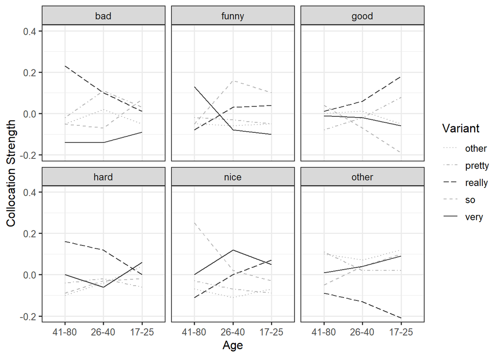

```r
ggplot(ampauscoll, aes(x = reorder(Age, desc(Age)),
                       y = phi, group = Variant,
                      color = Variant, linetype = Variant)) +
  facet_wrap(vars(Adjective)) +
  geom_line() +
  guides(color=guide_legend(override.aes=list(fill=NA))) +
  scale_color_manual(values =
                       c("gray70", "gray70", "gray20", "gray70", "gray20"),
                        name="Variant",
                        breaks = c("other", "pretty", "really", "so", "very"),
                        labels = c("other", "pretty", "really", "so", "very")) +
  scale_linetype_manual(values =
                          c("dotted", "dotdash", "longdash", "dashed", "solid"),
                        name="Variant",
                        breaks = c("other", "pretty", "really", "so", "very"),
                        labels = c("other",  "pretty", "really", "so", "very")) +
  theme(legend.position="top",
        axis.text.x = element_text(size=12),
        panel.grid.major = element_blank(),
        panel.grid.minor = element_blank()) +
  theme_set(theme_bw(base_size = 12)) +
  coord_cartesian(ylim = c(-.2, .4)) +
  labs(x = "Age", y = "Collocation Strength") +
  guides(size = FALSE)+
  guides(alpha = FALSE)
```

The results show that the collocation strength of different amplifier variants changes quite notably across age groups and we can also see that there is considerable variability in the way that the collocation strengths changes. For example, the collocation strengths between *bad* and *really* decreases from old to young speakers, while the reverse trend emerges for *good* which means that *really* is collocating more strongly with *good* among younger speakers than it is among older speakers.

# 6 Collostructional Analysis

Collostructional analysis (Stefanowitsch and Gries 2003, 2005) investigates the lexicogrammatical associations between constructions and lexical elements and there exist three basic subtypes of collostructional analysis:

- Simple Collexeme Analysis
- Distinctive Collexeme Analysis
- Co-Varying Collexeme Analysis

The analyses performed here are based on the `collostructions` package (Flach 2017).

## Simple Collexeme Analysis

NOTE!

The code in this section does not work at the moment as the `collostructions` package has not yet been updated and is therefore still incompatible with the R version used for this tutorial. The code is merely displayed and would work is processed with an older R versions.

Simple Collexeme Analysis determines if a word is significantly attracted to a specific construction within a corpus. The idea is that the frequency of the word that is attracted to a construction is significantly higher within the construction than would be expected by chance.

The example here analyzes the Go + Verb construction (e.g. *Go suck a nut!*). The question is which verbs are attracted to this constructions (in this case, if *suck* is attracted to this construction).

To perform these analyses, we use the `collostructions` package. Information about how to download and install this package can be found [here](https://userpage.fu-berlin.de/~flach/corpling/collostructions/.

In a first step, we load the collostructions package and inspect the data. In this case, we will only use a sample of 100 rows from the data set as the output would become hard to read.

```r
# load library
library(collostructions)
# draw a sample of the data
goVerb <- goVerb[sample(nrow(goVerb), 100),]
# inspect data
str(goVerb)
```

```
## 'data.frame':    100 obs. of  3 variables:
##  $ WORD     : Factor w/ 752 levels "accept","accomplish",..: 316 512 387 69 639 472 401 337 629 571 ...
##  $ CXN.FREQ : int  1 9 2 2 1 1 1 2 1 2 ...
##  $ CORP.FREQ: int  616 4355 23088 3403 661 155 5517 41167 2958 5276 ...
```

The collex function which calculates the results of a simple collexeme analysis requires a data frame consisting out of three columns that contain in column 1 the word to be tested, in column 2 the frequency of the word in the construction (CXN.FREQ), and in column 3 the frequency of the word in the corpus (CORP.FREQ).

To perform the simple collexeme analysis, we need the overal size of the corpus, the frequency with which a word occurs in the construction under investigation and the frequency of that construction.

```r
# define corpus size
crpsiz <- sum(goVerb$CORP.FREQ)
# perform simple collexeme analysis
scollex_results <- collex(goVerb, corpsize = crpsiz, am = "logl",
                          reverse = FALSE, decimals = 5,
                          threshold = 1, cxn.freq = NULL,
                          str.dir = FALSE)
# inspect results
head(scollex_results)
```

```
##   COLLEX CORP.FREQ  OBS   EXP ASSOC COLL.STR.LOGL SIGNIF
## 1    see    571660 1226 328.9  attr    1739.12842  *****
## 2 figure     67965  280  39.1  attr     639.85161  *****
## 3   read    199419  417 114.7  attr     502.02962  *****
## 4   look    271418  424 156.2  attr     335.28645  *****
## 5   pick     45487  134  26.2  attr     225.91310  *****
## 6    pee      1269   15   0.7  attr      62.36218  *****
```

The results show which words are significantly attracted to the construction. If the ASSOC column did not show *attr*, then the word would be repelled by the construction.

## Covarying Collexeme Analysis

Covarying collexeme analysis determines if the occurrence of a word in the first slot of a constructions affects the occurrence of another word in the second slot of the construction. As such, covarying collexeme analysis analyzes constructions with two slots and how the lexical elements within the two slots affect each other.

The data we will use consists of two columns which contain in the first column (CXN.TYPE) the word in the first slot (either *cannot* or *can’t*) and in the second slot (COLLEXEME) the word in the second slot, i.e. the collexeme, which the verb that follows after *cannot* or *can’t*. The first six rows of the data are shown below.

```r
head(cannot)
```

```
##   CXN.TYPE COLLEXEME
## 1   cannot       see
## 2    can't    figure
## 3    can't        do
## 4   cannot      deal
## 5   cannot     bring
## 6   cannot        be
```

We now perform the collexeme analysis and oinspect the results.

```r
covar_results <- collex.covar(cannot)
# inspect results
head(covar_results)
```

```
##    SLOT1    SLOT2  fS1 fS2 OBS   EXP ASSOC COLL.STR.LOGL SIGNIF
## 1 cannot       be  614 359 234  86.7  attr     328.47123  *****
## 2  can't remember 1929 127 127  96.3  attr      72.29136  *****
## 3  can't       do 1929 184 170 139.6  attr      36.83365  *****
## 4  can't      get 1929 132 123 100.1  attr      29.02213  *****
## 5  can't      see 1929 125 115  94.8  attr      23.20114  *****
## 6  can't     hear 1929  34  34  25.8  attr      18.93751   ****
```

The results show if a words in the first and second slot attract or repel each other (ASSOC) and provide uncorrceted significance levels.

## Distinctive Collexeme Analysis

Distinctive Collexeme Analysis determines if the frequencies of items in two alternating constructions or under two conditions differ significantly. This analysis can be extended to analyze if the use of a word differs between two corpora.

Again, we use the cannot data.

```r
collexdist_results <- collex.dist(cannot, raw = TRUE)
# inspect results
head(collexdist_results)
```

```
##     COLLEX O.CXN1 E.CXN1 O.CXN2 E.CXN2 ASSOC COLL.STR.LOGL SIGNIF SHARED
## 1 remember    127   96.3      0   30.7 can't      72.29136  *****      N
## 2       do    170  139.6     14   44.4 can't      36.83365  *****      Y
## 3      get    123  100.1      9   31.9 can't      29.02213  *****      Y
## 4      see    115   94.8     10   30.2 can't      23.20114  *****      Y
## 5     hear     34   25.8      0    8.2 can't      18.93751   ****      N
## 6    think     64   52.3      5   16.7 can't      14.00636    ***      Y
```

The results show if words are significantly attracted or repelled by either the contraction (*can’t*) or the full form (*cannot*). In this example, *remember* - like all other words shown in the results - is significantly attracted to the contraction (*can’t*).

# Citation & Session Info

Schweinberger, Martin. 2020. *Analyzing Co-Occurrences and Collocations in R*. Brisbane: The University of Queensland. url: https://slcladal.github.io/collocations.html (Version 2020.12.03).

```
@manual{schweinberger2020coll,
  author = {Schweinberger, Martin},
  title = {Analyzing Co-Occurrences and Collocations in R},
  note = {https://slcladal.github.io/collocations.html},
  year = {2020},
  organization = "The University of Queensland, Australia. School of Languages and Cultures},
  address = {Brisbane},
  edition = {2020/12/03}
}
```

[Main page](https://slcladal.github.io/index.html)

# References

Benoit, Kenneth, Kohei Watanabe, Haiyan Wang, Paul Nulty, Adam Obeng, Stefan Müller, and Akitaka Matsuo. 2018. “Quanteda: An R Package for the Quantitative Analysis of Textual Data.” *Journal of Open Source Software* 3 (30): 774. https://doi.org/10.21105/joss.00774.

Field, Andy, Jeremy Miles, and Zoe Field. 2012. *Discovering Statistics Using R*. Sage.

Flach, Susanne. 2017. “Collostructions: An R Implementation for the Family of Collostructional Methods.” Package version v.0.1.0. https://sfla.ch/collostructions/.

Stefanowitsch, Anatol, and Stefan Th. Gries. 2003. “Collostructions: Investigating the Interaction of Words and Constructions.” *International Journal of Corpus Linguistics* 8 (2): 209–43.

Stefanowitsch, Anatol, and Stefan Th Gries. 2005. “Covarying Collexemes.” *Corpus Linguistics and Linguistic Theory* 1 (1): 1–43.

Wiedemann, Gregor, and Andreas Niekler. 2017. “Hands-on: A Five Day Text Mining Course for Humanists and Social Scientists in R.” In *Proceedings of the Workshop on Teaching NLP for Digital Humanities (Teach4DH@GSCL 2017), Berlin, Germany, September 12, 2017.*, 57–65. http://ceur-ws.org/Vol-1918/wiedemann.pdf.